# R Lecture 1

# 設定工作目錄

`getwd()`

`setwd("C:\\Program Files\\R\\working")`

# 讀取資料

`read.table()` .txt, 以空白(“ “)或Tab(“”)做分隔。

`read.csv()` .csv, 以，分隔。

# 匯出資料

`write.csv(df, "df.csv", sep=",", col.names=TRUE)`

`write.table(df, "df.txt", quote=FALSE, sep="\t")`

# 預覽資料

`head()`, 前6筆

`tail()`, 後6筆

# summarize 資料

`str()` 列出資料內每個欄位的狀態

`summary()` 列出 5-number summary & mean

`names(), colnames()`得到變數名稱

`class()` 得到型態

`table(), mean(), min(), max(), range(), var(), sd(), cov()` `quantile(), quantile(變數, c(0.3, 0.7, 0.99))` `dim()` 給幾個row 幾個column

# 套件

`install.packages()` 裝套件

`library()` 匯入套件

# 向量化運算

`lapply(資料,fnc)`, `sapply()`

# 畫圖

- `plot(V1,V2)`
- `library(lattice)`

`xyplot(V2 ~ V1, data)` 以公式的方式來指定 x 與 y 軸的資料

`xyplot(V2 ~ V1 | 類別變數, data)`

- `library(ggplot2)`

`ggplot(data, aes(x = V1, y = V2)) +`

`geom_point()`

http://www.sthda.com/english/wiki/data-visualization

# 缺值

`is.na()` 是否有缺值

`data[!complete.cases(data),]` list rows of data that have missing values

`newdata <- na.omit(data)` create new dataset without missing data

`na.omit()` omit all rows containing missing values.

```r
data <- c(12, 4, 6, NA, 45, NA,99)
is.na(data) #是否是NA
```

```
## [1] FALSE FALSE FALSE  TRUE FALSE  TRUE FALSE
```

```r
which(is.na(data)) #哪個是NA
```

```
## [1] 4 6
```

```r
sum(is.na(data)) #幾個NA
```

```
## [1] 2
```

```r
mean(data) #有NA無法跑
```

```
## [1] NA
```

```r
mean(data, na.rm = TRUE) #除掉NA算
```

```
## [1] 33.2
```

```r
data[is.na(data)] <- mean(data, na.rm = TRUE) #NA用mean取代
data
```

```
## [1] 12.0  4.0  6.0 33.2 45.0 33.2 99.0
```

```r
data[data == 99] <- NA #99改成NA
data
```

```
## [1] 12.0  4.0  6.0 33.2 45.0 33.2   NA
```

# 例子-Car Sale

```r
setwd("~/Downloads")
print(load("carsale.Rda"))
```

```r
str(mydata)
summary(mydata)
class(mydata)
class(mydata[,1])
sapply(mydata, class)
```

```r
table(mydata$maker)
```

```
##
##           acura      alfa romeo             amc    aston martin
##             697               8               6               3
##            audi         bentley             bmw        bricklin
##             579              15            1657               1
##         bugatti           buick        cadillac       chevrolet
##               2             363             571            3394
##        chrysler          daewoo          datsun          desoto
##             835               5              16               2
##           dodge           eagle         ferrari            fiat
##            1841               6               4              35
##            ford    freightliner             geo             gmc
##            4266              39              24             684
## harley davidson           honda          hudson          hummer
##              15            2650               6              50
##         hyundai        infiniti   international           isuzu
##             876             559              66              50
##          jaguar            jeep             kia     lamborghini
##             127            1022             395               3
##      land rover            leaf           lexus         lincoln
##             148               8             786             307
##            mack        maserati           mazda        mercedes
##               7              17             550            1283
##         mercury              mg            mini      mitsubishi
##             230              19             215             363
##          nissan      oldsmobile       peterbilt         peugeot
##            2473             108               9               1
##        plymouth         pontiac         porsche     rolls royce
##              58             431             162              10
##            saab          saturn           scion          shelby
##             114             220             151              13
##           smart      studebaker          subaru          suzuki
##              25               5             531              93
##           tesla          toyota         triumph      volkswagen
##               9            3332               7            1116
##           volvo          willys         yerfdog             zap
##             371              12               2               1
```

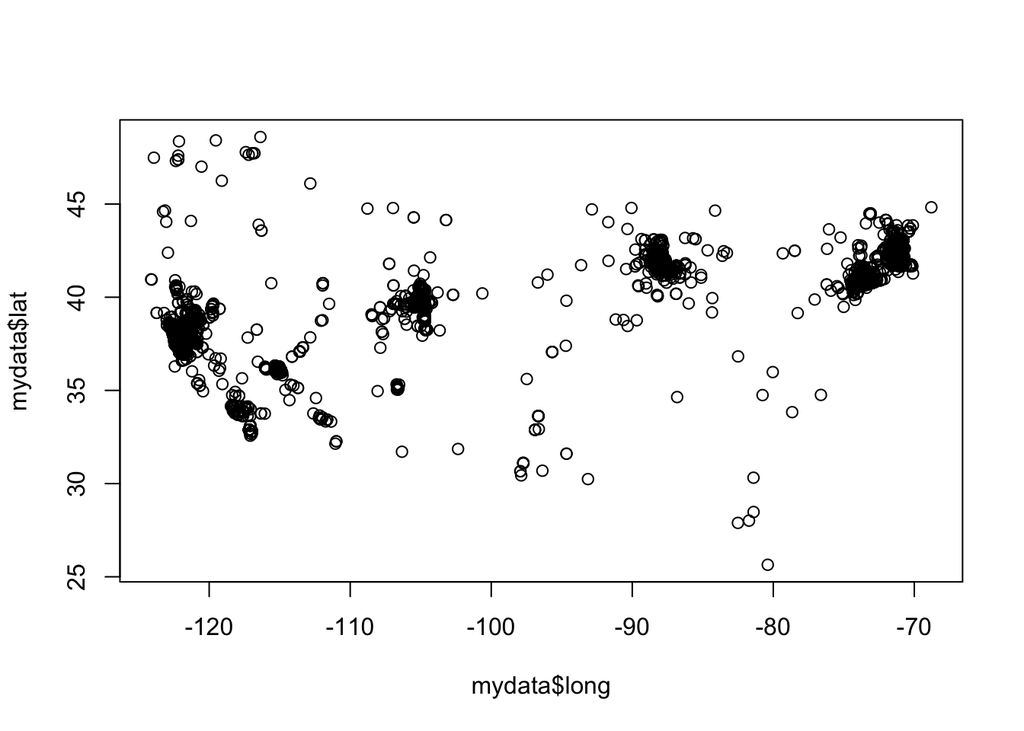

```r
plot(mydata$long,mydata$lat)
```

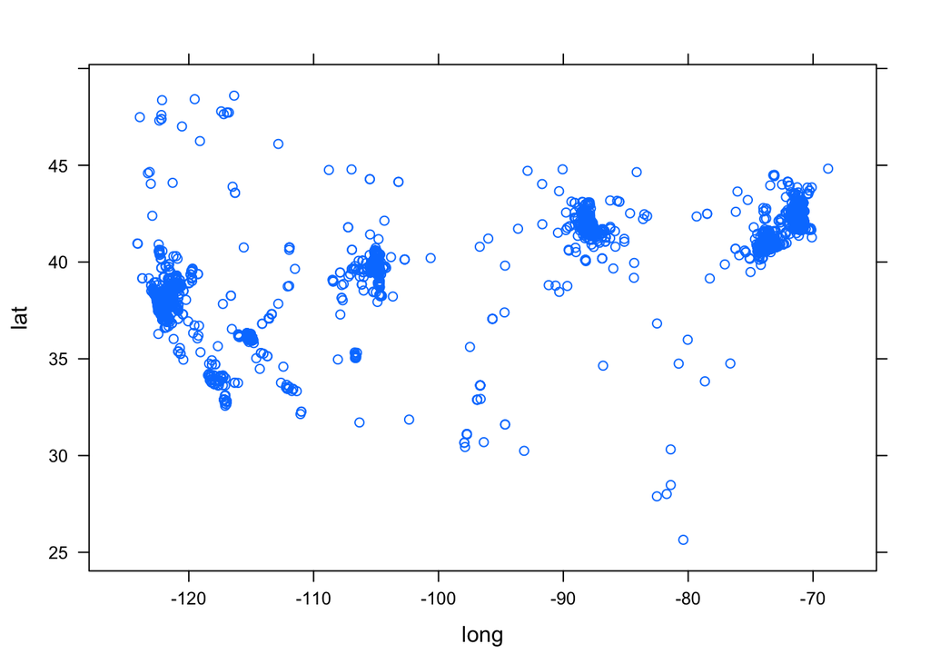

```r
library(lattice)
xyplot(lat ~ long, mydata)
```

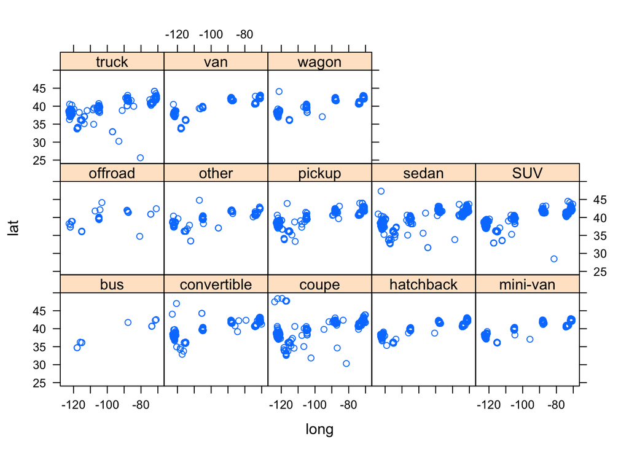

```r
xyplot(lat ~ long | type, mydata)
```

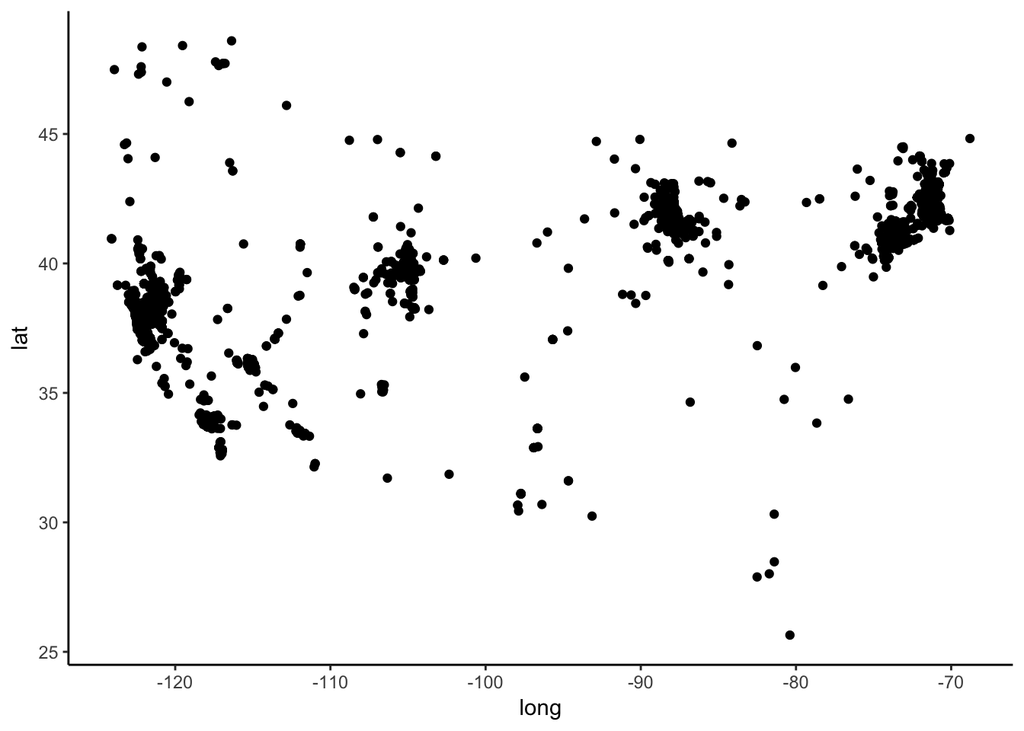

```r
#install.packages("ggplot2")
library(ggplot2)
ggplot(mydata, aes(x = long, y = lat)) +
  geom_point()+
  theme_classic()
```

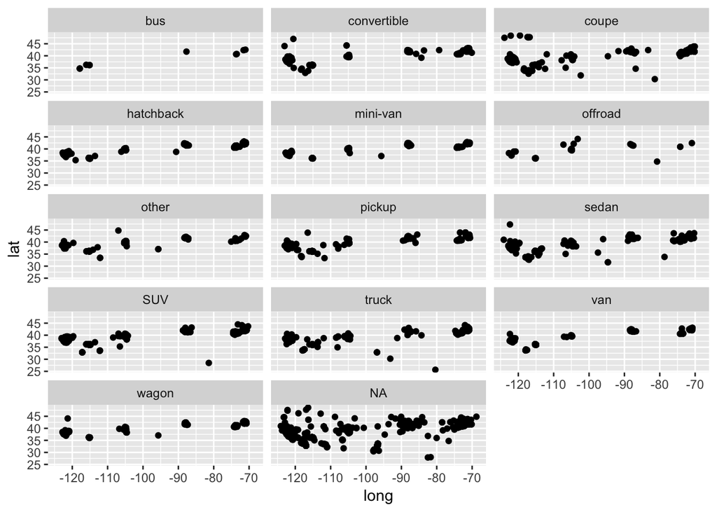

```r
ggplot(mydata, aes(x = long, y = lat)) +
  geom_point() +
  facet_wrap(~ type, ncol = 3)
```

```r
df_type = mydata[which(mydata$type != "NA"),] #去掉type有NA的
df = na.omit(mydata) #去掉所有NA
summary(df$city)
```

```
##   boston  chicago   denver lasvegas      nyc      sac    sfbay
##      459      290      336      312      346      287      362
```

```r
table(df$city)
```

```
##
##   boston  chicago   denver lasvegas      nyc      sac    sfbay
##      459      290      336      312      346      287      362
```

```r
levels(df$city)
```

```
## [1] "boston"   "chicago"  "denver"   "lasvegas" "nyc"      "sac"
## [7] "sfbay"
```

最貴的車？

```r
max(mydata$price,na.rm=T)
```

```
## [1] 30002500
```

```r
mydata[which.max(mydata$price),]$body
```

```
## [1] "\n        clean, fully loaded, nice shine, good running engine and trans, willing to trade for old school or truck?????????????????? Mounted on 22 inch rims new tires no bends no cracks\n    "
```

```r
median(c(6000,30000))
```

```
## [1] 18000
```

```r
mydata[which(mydata$price==max(mydata$price,na.rm=T)),]$price=median(c(6000,30000)) #用中位數取代
mydata[which.max(mydata$price),]$header #哪部車最貴
```

```
## [1] "2001 Honda Accord"
```

```r
head(sort(mydata$price,decreasing=T))
```

```
## [1] 9999999  569500  559500  400000  359000  286763
```

子集合

```r
bmw_df <- subset(df, maker=="bmw")
head(bmw_df)
```

|  | id | title | body | lat | long | posted | updated | drive | odometer | type | header | condition | cylinders | fuel | size | transmission | byOwner | city | time | description | location | url | price | year | maker | makerMethod |
| --- | --- | --- | --- | --- | --- | --- | --- | --- | --- | --- | --- | --- | --- | --- | --- | --- | --- | --- | --- | --- | --- | --- | --- | --- | --- | --- |
| posted23 | 5229007234 | 2008 BMW X5 3.0si,,ONLY 71K,,LIKE NEW,,1OWNER,SPORT PKG,NAVI,NEW TIRES - $19997 (Ashland) | \n 1OWNER 2008 X5 3.0SI IN A MINT CONDITION( HARD TO FIND WHITE ON BEIGE LEATHER). CLEAN CARFAX REPORT WITH ALL MAINTENANCE RECORDS.ALL SERVICES WAS DONE @BMW DEALER. THIS CAR HAS NO ACCIDENTS,NO PAIN… | 42.25173 | -71.45323 | 2015-09-19 21:42:25 | 2015-09-19 21:42:26 | 4wd | 71455 | SUV | 2008 bmw x5 3.0si | like new | 6 | gas | mid-size | automatic | FALSE | boston | 2015-09-20 00:42:00 | 2008 BMW X5 3.0si,,ONLY 71K,,LIKE NEW,,1OWNER,SPORT PKG,NAVI,NEW TIRES | (Ashland) pic map | /bmw/ctd/5229007234.html | 19997 | 2008 | bmw | 1.5 |
| posted100 | 5230459819 | 2008 BMW X5 3.0si,,ONLY 71K,,LIKE NEW,,1OWNER,SPORT PKG,NAVI,NEW TIRES - $19997 (Ashland) | \n 1OWNER 2008 X5 3.0SI IN A MINT CONDITION( HARD TO FIND WHITE ON BEIGE LEATHER). CLEAN CARFAX REPORT WITH ALL MAINTENANCE RECORDS.ALL SERVICES WAS DONE @BMW DEALER. THIS CAR HAS NO ACCIDENTS,NO PAIN… | 42.25173 | -71.45323 | 2015-09-20 21:58:50 | 2015-09-20 21:58:51 | 4wd | 71455 | SUV | 2008 bmw x5 3.0si | like new | 6 | gas | mid-size | automatic | FALSE | boston | 2015-09-21 00:58:00 | 2008 BMW X5 3.0si,,ONLY 71K,,LIKE NEW,,1OWNER,SPORT PKG,NAVI,NEW TIRES | (Ashland) pic map | /bmw/ctd/5230459819.html | 19997 | 2008 | bmw | 1.5 |
| posted552 | 5229211998 | 1999 BMW Z3M COUPE, SUPER CLEAN, ADULT OWNED, JUST SERVICED - $19500 (ATTLEBORO) | \n This is a very nice example of a the highly sought after 1999 BMW Z3 M COUPE, 98,500 miles, arctic silver exterior, black nappa interior, adult owned/ maintained, vehicle has never been raced/abuse… | 41.92960 | -71.30090 | 2015-09-19 23:50:31 | 2015-09-19 23:50:32 | rwd | 98500 | coupe | 1999 BMW m coupe | excellent | 6 | gas | compact | manual | FALSE | boston | 2015-09-20 02:50:00 | 1999 BMW Z3M COUPE, SUPER CLEAN, ADULT OWNED, JUST SERVICED | (ATTLEBORO) pic map | /gbs/ctd/5229211998.html | 19500 | 1999 | bmw | 1.5 |
| posted554 | 5229216463 | 2002 BMW 330XI, SUPER CLEAN, ALL WHEEL DRIVE, M SPORT - $6999 (ATTLEBORO) | \n 2002 BMW 330XI, automatic transmission, 115k miles, adult owned, just serviced by BMW, car runs and drives like new. Trades are accepted and financing is available. For more info please email or ca… | 41.92960 | -71.30090 | 2015-09-19 23:52:59 | 2015-09-19 23:53:01 | 4wd | 115888 | sedan | 2002 BMW 330XI | excellent | 6 | gas | mid-size | automatic | FALSE | boston | 2015-09-20 02:52:00 | 2002 BMW 330XI, SUPER CLEAN, ALL WHEEL DRIVE, M SPORT | (ATTLEBORO) pic map | /gbs/ctd/5229216463.html | 6999 | 2002 | bmw | 1.5 |
| posted817 | 5230493753 | 2007 BMW 525Xi - $9975 (Legendary Motors Braintree) | \n Very nice clean well maintained BMW that is equipped nicely options and ready for winter with AWD\nGreat CarFax report; No accidents and 13 service records available.\nCarFax appraises this vehicle… | 42.20930 | -70.99630 | 2015-09-20 22:28:03 | 2015-09-22 09:48:04 | 4wd | 121085 | sedan | 2007 BMW 525Xi | excellent | 6 | gas | full-size | automatic | FALSE | boston | 2015-09-21 01:28:00 | 2007 BMW 525Xi | (Legendary Motors Braintree) pic map | /gbs/ctd/5230493753.html | 9975 | 2007 | bmw | 1.5 |
| posted934 | 5231714466 | 2013 BMW X5 PREMIUM SPRT.22K MILES ONE OWNER CLEAN CARFAX.LIKE NEW - $38990 (DEDHAM) | \n 2013 BMW X5 PREMIUM SUV. 23K MILES. THIS CAR STILL UNDER FACTORY WARRANTY AND LIKE NEW.LOADED premium pkg cold weather pkg NAVIGATION BACKUP CAM.. SUNROOF SIDE STEPS.POWER LIFTGATE. IF YOU HAVE ANY… | 42.24370 | -71.16370 | 2015-09-21 19:47:13 | 2015-09-21 19:47:14 | 4wd | 22 | SUV | 2013 bmw x5 xdrive35i | excellent | 6 | gas | full-size | automatic | FALSE | boston | 2015-09-21 22:47:00 | 2013 BMW X5 PREMIUM SPRT.22K MILES ONE OWNER CLEAN CARFAX.LIKE NEW | (DEDHAM) pic map | /gbs/ctd/5231714466.html | 38990 | 2013 | bmw | 1.5 |

```r
subset(df, price > 40000, select = c(price, maker,type))
```

|  | price | maker | type |
| --- | --- | --- | --- |
| posted1254 | 51400 | chrysler | mini-van |
| posted13541 | 42000 | mercedes | coupe |
| posted14921 | 49000 | dodge | coupe |
| posted22901 | 41800 | land rover | SUV |
| posted16515 | 49000 | gmc | SUV |
| posted21263 | 45800 | chevrolet | sedan |
| posted3618 | 43500 | lexus | SUV |
| posted13245 | 105000 | ford | sedan |
| posted17020 | 43748 | chevrolet | truck |
| posted18220 | 41783 | chevrolet | truck |

[output cut: 12 more lines]

```r
subset(df, price > 40000 & type=='SUV', select = c(price, maker, type))
```

|  | price | maker | type |
| --- | --- | --- | --- |
| posted22901 | 41800 | land rover | SUV |
| posted16515 | 49000 | gmc | SUV |
| posted3618 | 43500 | lexus | SUV |
| posted16148 | 48999 | gmc | SUV |
| posted20339 | 48000 | gmc | SUV |